## Úkol 2.1

Ze stránek České národní banky (odrážka Statistika – systém časových řad ARAD) si stáhněte nejdelší možnou časovou řadu objemu úvěrů poskytnutých nefinančním podnikům (stav úvěrů, nikoli nově poskytnuté úvěry). Tuto řadu si zobrazte v grafu a i s využitím různých transformací časové řady se pokuste odhalit co nejvíce prvků neobvyklého chování, které tato řada vykazuje („neobvyklé“ = chování řady nepodložené čistě hospodářským vývojem) – aneb poznejte svá data před samotným využitím v modelu.

1. Pro nalezené „neobvyklé“ prvky se pokuste vytvořit logické hypotézy, které by tento vývoj v časové řadě mohly vysvětlovat.
2. Své hypotézy ověřte/podpořte pomocí zdrojů nalezených na internetu (novinové články, učebnice, webové stránky ČNB či dalších finančních institucí).
3. Vyhodnoťte, nakolik identifikované prvky ovlivňují ekonomickou vypovídací schopnost časové řady.

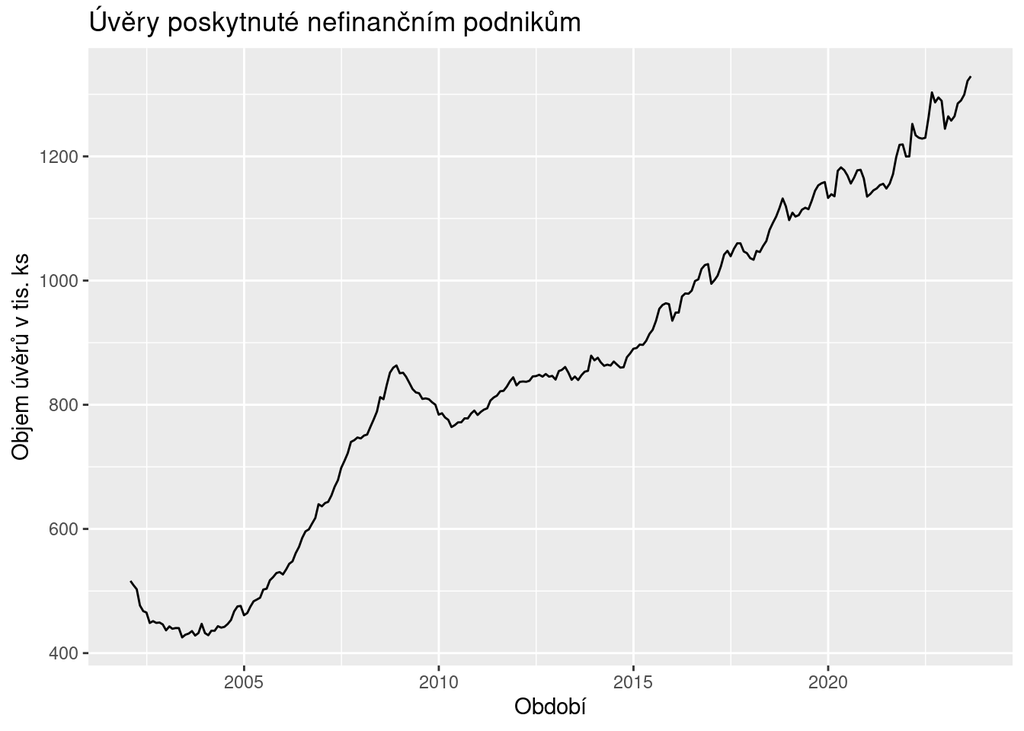

```r
library(ggplot2)

dataPom <- read.csv("ARAD-uvery.csv", sep = ";")
dataPom[,5] <- gsub(',', '.', dataPom[,5])

dataARAD <- as.data.frame(matrix(ncol = 0, nrow = nrow(dataPom)))

dataARAD$obdobi <- as.Date(dataPom[,1], "%Y-%m-%d")
dataARAD$uvery <- as.numeric(dataPom[,5])
dataARAD$uveryTis <- dataARAD$uvery/1000

dataARAD <- dataARAD[order(dataARAD[,1]),]

ggplot(dataARAD, aes(x = obdobi, y = uveryTis)) +
  geom_line() +
  xlab("Období") + ylab("Objem úvěrů v tis. ks") + ggtitle("Úvěry poskytnuté nefinančním podnikům")
```

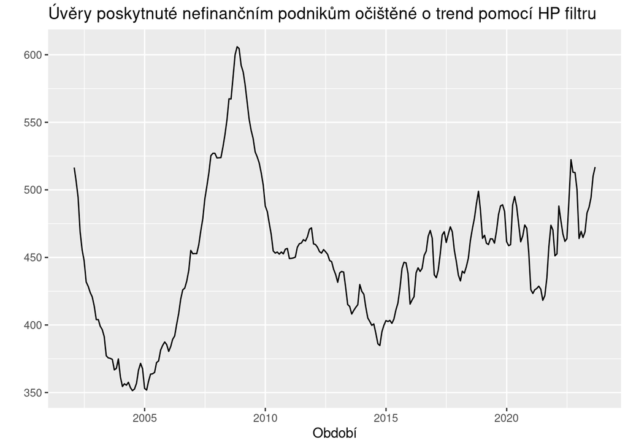

```r
library(mFilter)
dataARAD$uveryTis_bezT_hp1 <- hpfilter(dataARAD$uveryTis,freq=2,type="frequency", drift=TRUE)$trend

ggplot(dataARAD, aes(x = obdobi, y = uveryTis_bezT_hp1)) +
  geom_line() +
  xlab("Období") + ylab("")  + ggtitle("Úvěry poskytnuté nefinančním podnikům očištěné o trend pomocí HP filtru")
```

#### Nízký objem poskytnutých úvěrů v roce 2005

V roce 2005 se uskutečnil historicky největší růst ekonomiky. Ten se uskutečnil v nízkoinflačním prostředí, když inflace byla nižší při posilování devizového kurzu CZK. k čemuž nejvíce přispěly výsledky zahraničního obchodu zbožím. Vývoj zahraničně ekonomických vztahů byl klíčovým jevem vysokého a zrychlujícího se růstu HDP a rozhodujícím činitelem zlepšení souhrnné ekonomické pozice, které se projevilo ve snížení rozsahu vnitřní a vnější nerovnováhy.

https://www.czso.cz/documents/10180/20549847/1109-05-q4-int.pdf/c53e6c0e-1e15-4a53-8d06-68567cdf7a33?version=1.0

#### Vysoký objem poskytnutých úvěrů v roce 2008

Za vysvětlením tohoto vysokého objemu poskytnutých úvěrů je Velká recese. Prvotní příčinou byla americká hypoteční krize, která postupně přerostla ve světovou finanční krizi, významnou roli sehrála rovněž vysoká cena ropy v první polovině roku 2008, která vedla k poklesu reálného HDP a zvedla spotřebitelské ceny.

https://cs.wikipedia.org/wiki/Velká_recese

## Úkol 2.2

Z databáze Eurostatu si stáhněte data o českých spotřebitelských cenách v nejdelší možné délce časové řady. Pomocí Bertinovy matice a jejího přeuspořádání se pokuste data vizuálně zanalyzovat. K přeuspořádání matice použijte ztrátovou funkci STRESS. K nalezení minima ztrátové funkce použijte evoluční algoritmy.

1. Data upravte tak, abyste dále pracovali s mírou inflace, tj. s meziročními změnami indexu. Data redukujte na čtvrtletní frekvenci (meziroční změny v březnu, červnu, září a prosinci).
2. Shrňte všechny zajímavé závěry, které jsou z grafu (tj. přeuspořádané Bertinovy matice) patrné. Které položky se vyvíjejí obdobně? K jakým změnám ve složení inflačních tlaků dochází? Jak se vyvíjí inflace napříč hospodářským cyklem a které položky s vývojem hospodářského cyklu nejvíce souvisejí? Které položky jsou velmi volatilní (a jsou volatilní tím způsobem, že kolísají s hospodářským cyklem)?

```r
data_neocistena <- as.data.frame(read.csv("prc_hicp_midx_page_linear 3.csv"))
data_neocistena <- data_neocistena[-which(data_neocistena$coicop == "CP09142"),]
data_neocistena <- data_neocistena[-which(data_neocistena$coicop == "CP02203"),]

dataHICP <- as.data.frame(matrix(nrow = length(table(data_neocistena$TIME_PERIOD)), ncol = 0))
coicop <- unique(data_neocistena$coicop)

for(i in 1:169){
  dataHICP[,i] <- data_neocistena[data_neocistena$coicop == coicop[i],]$OBS_VALUE
}

rownames(dataHICP) <- unique(data_neocistena$TIME_PERIOD)
colnames(dataHICP) <- coicop
```

```r
dataHICP2 <- as.data.frame(matrix(ncol = ncol(dataHICP), nrow = (nrow(dataHICP)-12)))
colnames(dataHICP2) <- colnames(dataHICP)

for(i in 1:96){
  dataHICP2[i,] <- dataHICP[(i+12),]/dataHICP[i,]
}

rownames(dataHICP2) <- rownames(dataHICP)[13:108]

dataHICP2 <- dataHICP2[seq(from = 1, to = 96, by = 2),]
```

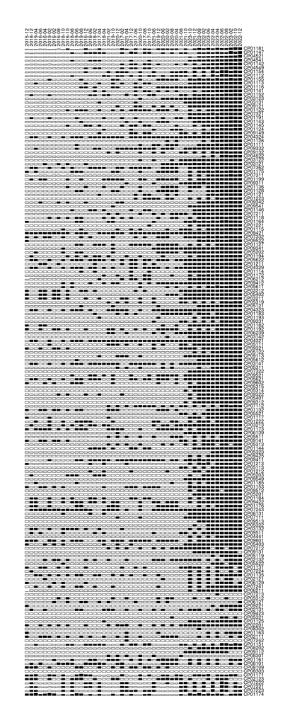

```r
library(seriation)
order <- c(
  seriate(dist(as.matrix(dataHICP2), "minkowski", p = 1)),
  seriate(dist(t(as.matrix(dataHICP2)), "minkowski", p = 1))
)

bertinplot(as.matrix(dataHICP2), order)
```